# Intermediate Portfolio Analysis in R

Notes on DataCamp’s [Intermediate Portfolio Analysis in R](https://www.datacamp.com/courses/intermediate-portfolio-analysis-in-r) class.

This uses the PortfolioAnalytics class. Note this is not the PerformanceAnalytics package used in the first course in this series.

```r
library(PortfolioAnalytics)
data(edhec) # sample hedge fund returns
```

# Chapter 1 - Introduction and MPT

Builds on the intro class. Explores advanced concepts.

MPT - Modern Portfolio Theory (Markowitz 1952) Maximizing return (mean return) for a given level of risk (std deviation). Most modern implementations implement several differnet measures for return & risk.

PortfolioAnalytics uses a spec of the investment vehicles, constriaints on how to invest, and objectives which specify how to measure returns and risk.

You can then print the portfolio spec to see the details, then run `optimize.portfolio` to solve the problem. `chart.RiskReward` is one built in viz format for the results.

Here we setup the environment, load a default data set included with the library, and subset the data.

```r
# Load the pacakge
library(PortfolioAnalytics)
# Load the data
data(indexes)
# Subset the data
index_returns <- indexes[, 1:4]
# Print the head of the data
head(index_returns)
```

```
           US Bonds US Equities Int'l Equities
1980-01-31  -0.0272      0.0610         0.0462
1980-02-29  -0.0669      0.0031        -0.0040
1980-03-31   0.0053     -0.0987        -0.1188
1980-04-30   0.0992      0.0429         0.0864
1980-05-31   0.0000      0.0562         0.0446
1980-06-30   0.0605      0.0296         0.0600
           Commodities
1980-01-31      0.0568
1980-02-29     -0.0093
1980-03-31     -0.1625
1980-04-30      0.0357
1980-05-31      0.0573
1980-06-30      0.0533
```

```r
library("ROI")
# Create the portfolio specification
port_spec <- portfolio.spec(colnames(index_returns))
# Add a full investment constraint such that the weights sum to 1
port_spec <- add.constraint(portfolio = port_spec, type = "full_investment")
# Add a long only constraint such that the weight of an asset is between 0 and 1
port_spec <- add.constraint(portfolio = port_spec, type = "long_only")
# Add an objective to minimize portfolio standard deviation
port_spec <- add.objective(portfolio = port_spec, type = "risk", name = "StdDev")
# Solve the optimization problem
opt <- optimize.portfolio(index_returns, portfolio = port_spec, optimize_method = "ROI")
```

## Displaying the results of simple optimization

```r
# Print the results of the optimization
opt

# Extract the optimal weights
extractWeights(opt)

# Chart the optimal weights
chart.Weights(opt)
```

## Maximizing Quad Utility

```r
# Create the portfolio specification
port_spec <- portfolio.spec(assets = colnames(index_returns))
# Add a full investment constraint such that the weights sum to 1
port_spec <- add.constraint(portfolio = port_spec, type = "full_investment")
# Add a long only constraint such that the weight of an asset is between 0 and 1
port_spec <- add.constraint(portfolio = port_spec, type = "long_only")
# Add an objective to maximize portfolio mean return
port_spec <- add.objective(portfolio = port_spec, type = "return", name = "mean")
# Add an objective to minimize portfolio variance
port_spec <- add.objective(portfolio = port_spec, type = "risk", name = "quadratic_utility", risk_aversion = 10)
# Solve the optimization problem
opt <- optimize.portfolio(R = index_returns, portfolio = port_spec, optimize_method = "ROI")
```

```
Error in optimize.portfolio(R = index_returns, portfolio = port_spec,  :
  ROI only solves mean, var/StdDev, HHI, or sample ETL/ES/CVaR type business objectives, choose a different optimize_method.
```

# Chapter 2 - Portfolio Optimization Workflow

Steps:

1. Create protfolio specificaiton
2. Add constraints and objectives
3. Run optimization
4. Analyze output of optimization

## Portfolio Specification

```r
# Get the column names of the returns data
asset_names <- colnames(asset_returns)
```

```
Error in is.data.frame(x) : object 'asset_returns' not found
```

## Add Constraints

Adding three constraints

1. full_investment
2. minimum weights of 10% on first 5 and 5% on all remaining assets, with max investment in any one asset of 0.4
3. create two groups of assets, with min weighting of 40% and max weighting o 60% for each group

```r
# Add the weight sum constraint
port_spec <- add.constraint(portfolio = port_spec, type = "weight_sum", min_sum = 1, max_sum = 1)

# Add the box constraint
port_spec <- add.constraint(portfolio = port_spec, type = "box", min = c(rep(.1, 5), rep(0.05, 13-5)), max = 0.4)

# Add the group constraint
port_spec <- add.constraint(portfolio = port_spec, type = "group", groups = list(c(1, 5, 7, 9, 10, 11), c(2, 3, 4, 6, 8, 12)), group_min = 0.4, group_max = .6)


# Print the portfolio specification object
print(port_spec)
```

## Add objectives

Add objectives to the portfolio. In addition to the standard return and risk types we’ve seen before, this adds a third objective type of `risk_budget` which seeks to keep the individual contribution to portfolio risk within certain parameters.

```r
# Add a return objective to maximize mean return
port_spec <- add.objective(portfolio = port_spec, type = "return", name = "mean")

# Add a risk objective to minimize portfolio standard deviation
port_spec <- add.objective(portfolio = port_spec, type = "risk", name = "StdDev")

# Add a risk budget objective
port_spec <- add.objective(portfolio = port_spec, type = "risk_budget", name = "StdDev", min_prisk = .05, max_prisk = .10)

# Print the portfolio specification object
print(port_spec)
```

## Optimization

```r
# Run a single period optimization using random portfolios as the optimization method
opt <- optimize.portfolio(R = asset_returns, portfolio = port_spec, optimize_method = "random", rp = rp, trace = TRUE)

# Print the output of the single-period optimization
print(opt)
```

## Optimization with period rebalancing

rp is set to 500 for the number of random portfolio permutations.

The data is monthly, so 60 training and rolling window period will give 5 year lookback.

```r
# Run the optimization backtest with quarterly rebalancing
opt_rebal <- optimize.portfolio.rebalancing(R = asset_returns, portfolio = port_spec, optimize_method = "random", rp = rp, trace = TRUE, rebalance_on = "quarters", training_period = 60, rolling_window = 60)


# Print the output of the optimization backtest
print(opt_rebal)
```

## Analyzing Optimization Results

```r
# Extract the objective measures for the single period optimization
extractObjectiveMeasures(opt)

# Extract the objective measures for the optimization backtest
extractObjectiveMeasures(opt_rebal)
```

## Optimal Weights

```r
# Extract the optimal weights for the single period optimization
extractWeights(opt)

# Chart the weights for the single period optimization
chart.Weights(opt)

# Extract the optimal weights for the optimization backtest
extractWeights(opt_rebal)


# Chart the weights for the optimization backtest
chart.Weights(opt_rebal)
```

# Chapter 3 - Objective Functions

Sample Moment Estimates

portfolio.moments are calculated based upon the objectives that are set on the port_spec object.

```r
# Add a return objective with "mean" as the objective name
port_spec <- add.objective(portfolio = port_spec, type = "return", name = "mean")

# Calculate the sample moments
moments <- set.portfolio.moments(R = asset_returns, portfolio = port_spec)

# Check if moments$mu is equal to the sample estimate of mean returns
moments$mu == colMeans(asset_returns)

# Add a risk objective with "StdDev" as the objective name
port_spec <- add.objective(portfolio = port_spec, type = "risk", name = "StdDev")

# Calculate the sample moments using set.portfolio.moments. Assign to a variable named moments.
moments <- set.portfolio.moments(R = asset_returns, portfolio = port_spec)

# Check if moments$sigma is equal to the sample estimate of the variance-covariance matrix
moments$sigma == cov(asset_returns)
```

## Advanced Moment Estimates

Use the boundt statsitical factor model to calculate the first four moments.

```r
# Print the portfolio specification object
print(port_spec)

# Fit a statistical factor model to the asset returns
fit <- statistical.factor.model(R = asset_returns, k =3)

# Estimate the portfolio moments using the "boudt" method with 3 factors
moments_boudt <- set.portfolio.moments(R = asset_returns, portfolio = port_spec, method = "boudt", k = 3)

# Check if the covariance matrix extracted from the model fit is equal to the estimate in `moments_boudt`

# Check if the covariance matrix extracted from the model fit is equal to the estimate in `moments_boudt`
moments_boudt$sigma == extractCovariance(fit)
```

```r
# Print the portfolio specification object
print(port_spec)

# Fit a statistical factor model to the asset returns
fit <- statistical.factor.model(R = asset_returns, k =3)

# Estimate the portfolio moments using the "boudt" method with 3 factors
moments_boudt <- set.portfolio.moments(R = asset_returns, portfolio = port_spec, method = "boudt", k = 3)

# Check if the covariance matrix extracted from the model fit is equal to the estimate in `moments_boudt`

# Check if the covariance matrix extracted from the model fit is equal to the estimate in `moments_boudt`
moments_boudt$sigma == extractCovariance(fit)
```

Optimization with custom moment function

```r
# Run the optimization with custom moment estimates
opt_custom <- optimize.portfolio(R = asset_returns, portfolio = port_spec, optimize_method = "random", rp = rp, momentFUN = "moments_robust")

# Print the results of the optimization with custom moment estimates
print(opt_custom)

# Run the optimization with sample moment estimates
opt_sample <- optimize.portfolio(R = asset_returns, portfolio = port_spec, optimize_method = "random", rp = rp)

# Print the results of the optimization with sample moment estimates
print(opt_sample)
```

## Custom Objective Function

```r
# Custom annualized portfolio standard deviation
pasd <- function(R, weights, sigma, scale = 12){
  sqrt(as.numeric(t(weights) %*% sigma %*% weights)) * sqrt(scale)
}
```

## Using custom objective functions for optimization

```r
# Add custom objective to portfolio specification
port_spec <- add.objective(portfolio = port_spec, type = "risk", name = "pasd")

# Print the portfolio specificaton object
print(port_spec)

# Run the optimization
opt <- optimize.portfolio(R = asset_returns, portfolio = port_spec, momentFUN = set_sigma, optimize_method = "random", rp = rp)

# Print the results of the optimization
print(opt)
```

# Chapter 4 Application

## Compute benchmark returns

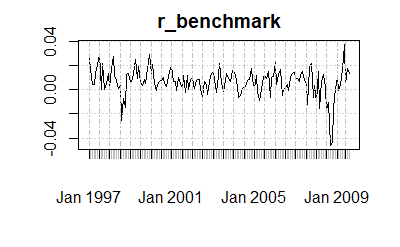

```r
# Load the package
library(PortfolioAnalytics)
# Load the data
data(edhec)
# Assign the data to a variable
asset_returns <- edhec
# Create a vector of equal weights
equal_weights <- rep(1 / ncol(asset_returns), ncol(asset_returns))
# Compute the benchmark returns
r_benchmark <- Return.portfolio(R = asset_returns, weights = equal_weights, rebalance_on = "quarters")
colnames(r_benchmark) <- "benchmark"
# Plot the benchmark returns
plot(r_benchmark)
```

Create basic portfolio optimization

```r
# Create the portfolio specification
port_spec <- portfolio.spec(colnames(asset_returns))

# Add a full investment constraint such that the weights sum to 1
port_spec <- add.constraint(port_spec, type="full_investment")

# Add a long only constraint such that the weight of an asset is between 0 and 1
port_spec <- add.constraint(port_spec, type="long_only")

# Add an objective to minimize portfolio standard deviation
port_spec <- add.objective(port_spec, type="risk", name="StdDev")

# Print the portfolio specification
print(port_spec)
```

## Backtest with Periodic Rebalancing

```r
# Run the optimization
opt_rebal_base <- optimize.portfolio.rebalancing(R = asset_returns,
                                                 portfolio = port_spec,
                                                 optimize_method = "ROI",
                                                 rebalance_on = "quarters",
                                                 training_period = 60,
                                                 rolling_window = 60)

# Print the results
print(opt_rebal_base)

# Chart the weights
chart.Weights(opt_rebal_base)

# Compute the portfolio returns
returns_base <- Return.portfolio(R = asset_returns, weights = extractWeights(opt_rebal_base))
colnames(returns_base) <- "base"
```

## Refine constraints and objectives

```r
# Add a risk budget objective
port_spec <- add.objective(portfolio = port_spec,
                           type = "risk_budget",
                           name = "StdDev",
                           min_prisk = .05,
                           max_prisk = .10)

# Run the optimization
opt_rebal_rb <- optimize.portfolio.rebalancing(R = asset_returns,
                                               portfolio = port_spec,
                                               optimize_method = "random", rp = rp,
                                               trace = TRUE,
                                               rebalance_on = "quarters",
                                               training_period = 60,
                                               rolling_window = 60)

# Chart the weights
chart.Weights(opt_rebal_rb)

# Chart the percentage contribution to risk
chart.RiskBudget(opt_rebal_rb, match.col = "StdDev", risk.type = "percentage")

# Compute the portfolio returns
returns_rb <- Return.portfolio(R = asset_returns, weights = extractWeights(opt_rebal_rb))
colnames(returns_rb) <- "risk_budget"
```

## checking if imrpove estimates lead to improved performance

```r
# Run the optimization
opt_rebal_rb_robust <- optimize.portfolio.rebalancing(R = asset_returns,
                                                      momentFUN = "moments_robust",
                                                      portfolio = port_spec,
                                                      optimize_method = "random", rp = rp,
                                                      trace = TRUE,
                                                      rebalance_on = "quarters",
                                                      training_period = 60,
                                                      rolling_window = 60)

# Chart the weights
chart.Weights(opt_rebal_rb_robust)


# Chart the percentage contribution to risk
chart.RiskBudget(opt_rebal_rb_robust, match.col = "StdDev", risk.type = "percentage")

# Compute the portfolio returns
returns_rb_robust <- Return.portfolio(R = asset_returns, weights = extractWeights(opt_rebal_rb_robust))
colnames(returns_rb_robust) <- "rb_robust"
```

## analyze and compare to benchmark

```r
# Combine the returns
ret <- cbind(r_benchmark, returns_base, returns_rb, returns_rb_robust)

# Compute annualized returns
table.AnnualizedReturns(R = ret)

# Chart the performance summary
charts.PerformanceSummary(R = ret)
```